# Tiered Framework Assessment for Chemical Prioritization

Jesse Rogers

December 15, 2023

Assessment of current chemical screening data using a tiered NAM-based framework to prioritize chemicals that perturb key molecular targets.

Chemicals are screened in Tier 1 using Reference Class Associated Signatures (RCAS), initially for bioactivity (Tier 1-Positive) and additionally for selectivity versus non-targeted transcriptional responses (Tier 1-Selective). Chemicals with sufficient evidence of targeted behavior in Tier 1 are advanced to confirmatory Tier 2 assays from the [US EPA ToxCast program](https://www.epa.gov/chemical-research/exploring-toxcast-data) using bioactivity and selectivity criteria.

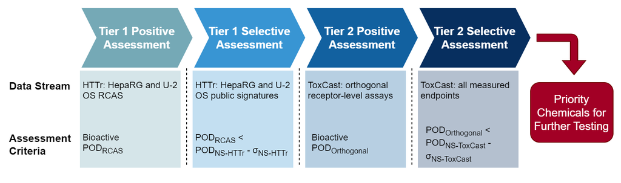

This framework was applied to 1,201 chemicals screened using high-throughtput transcriptomics (HTTr). Chemicals with existing, orthogonal assay data in ToxCast were used for retrospective evaluation of the framework’s performance, and a subset of chemicals with no orthogonal data were tested in a series of targeted assays as a prospective screen of data-poor chemicals.

**Note**: Functions import ToxCast from InvitroDB using an internal MySQL database and is only available for internal use. However, this method can be altered to work with a local instance of InvitroDB [available for public download](https://www.epa.gov/chemical-research/exploring-toxcast-data).

# 1 Setup Environment

```r
# import packages for visualization
# (note that other required packages will be imported by pipeline scripts)
library(ggplot2)
library(ComplexHeatmap)
library(RColorBrewer)
library(circlize)
library(ggsankey)
library(ggupset)
library(ggsignif)
library(ggrepel)
library(stringr)

# set directories (`dir_home` should be set to the top-level directory)
dir_home <- "~/NAM-integration/NAM-integration-pilot-packaged/"
dir_scripts <- paste0(dir_home, "scripts/")
setwd(dir_home)

# import scripts/data for RCAS profiling and framework assessment
source(paste0(dir_scripts, "pipeline_RCAS_profiling.R"))
source(paste0(dir_scripts, "pipeline_HTS_selection.R"))
source(paste0(dir_scripts, "pipeline_framework.R"))

path_rcas <- c(
  paste0(dir_home, "data/examples/rcas_heparg_gene.RData"),
  paste0(dir_home, "data/examples/rcas_u2os_gene.RData")
)

th <- theme(text = element_text(family = "Helvetica"))
th_sankey <- theme_sankey(base_family = "Helvetica")

# import tier 2 annotations for endpoint abbreviations (Table 1 from main text)
tier2_annot <- read.csv(
  paste0(dir_home, "data/Table1_Tier2Annotations.csv"),
  stringsAsFactors = FALSE
)

# import reference chemical annotations per cell line
rcas_heparg <- selectRCASGenes(path_rcas[1])
rcas_u2os <- selectRCASGenes(path_rcas[2])
```

# 2 Select Orthogonal ToxCast Endpoints

Receptor-level endpoints from ToxCast are first selected for use in the tiered framework as those that can distinguish in-class chemicals (i.e. those known to activate/inhibit the target) from out-of-class chemicals (those known to modulate some other target). RefChemDB annotations are used to designate in-class/out-of-class chemicals (agnostic of RCAS). Bioactivity classification performance and Wilcoxon rank-sum tests for potency estimates are used to test whether each assay can delineate chemical categories.

Here, endpoints have been pre-selected using 13 reference chemical classes specified during RCAS generation, and ToxCast data for pre-selected endpoints are saved in the `data/examples` directory. Note that this script only needs to be run once for all analyses (and not per target).

```r
# set molecular targets for select assays for
# (manually set to those used for RCAS generation)
cluster_targets <- c(
  "ESR1_Positive", "AHR_Positive", "PTGS2_Negative",
  "AR_Positive", "RARA_Positive", "PPARA_Positive",
  "CA1_Negative|CA2_Negative", "CA1_Positive|CA2_Positive",
  "AR_Negative", "CYP19A1_Negative",
  "CA1_Negative|CA12_Negative|CA2_Negative|CA9_Negative",
  "KCNH2_Negative", "NR3C1_Positive"
)
# run assay selection for specified targets
# (filtered mc5/sc2 tables loaded from pre-generated tables)
path_mc5_selected <- paste0(
  dir_home, "data/examples/invitrodb_v3_4_selected.RData"
)
path_mc5_burst <- paste0(
  dir_home, "data/examples/invitrodb_v3_4_burst.RData"
)
path_mc5_ace <- paste0(
  dir_home, "data/examples/invitrodb_v3_4_assay_information.RData"
)
path_refchem <- paste0(dir_home, "data/examples/refchemdb_clusters.RData")
selectHTSEndpoints(
  cluster_targets,
  path_mc5_selected,
  filepath_save_burst = path_mc5_burst,
  filepath_load_refchem = path_refchem
)
```

# 3 Generate Framework Results

Using previous HTTr (Tier 1) and ToxCast (Tier 2) targeted potency estimates, the framework above is used to evaluate 1,201 chemicals screened in HTTr across HepaRG and U-2 OS cell lines.

Here, tiered framework results have been pre-generated using RCAS potency estimates generated in the RCAS analysis vignette, and results for each cell line are saved in the `data/examples` directory.

Note: `path_catalog` refers to previously generated signature-level concentration-response profiles for 11,037 signatures in the HTTr signature catalog in HepaRG and U-2 OS cell lines. Here, data are pulled for each cell line from an internal directory, but data are available to view and download publicly on the [EPA CompTox Chemicals Dashboard](https://comptox.epa.gov/dashboard/).

```r
# run tiered framework for heparg2d and u2os RCAS
path_cr <- c(
  "SIGNATURE_CR_rcas_res_httr_heparg2d_toxcast_gsea_0.05_conthits.RData",
  "SIGNATURE_CR_rcas_res_httr_u2os_toxcast_gsea_0.05_conthits.RData"
)
path_catalog <- paste0(
  "/ccte/projects1/HTTr/screen_signature_cr/signature_conc_resp/",
  "SIGNATURE_CR_screen_large_",
  c(
    "heparg2d_toxcast_pfas_pe1_normal_v2_gsea_0.05_conthits.RData",
    "u2os_toxcast_pfas_pe1_normal_v2_gsea_0.05_conthits.RData"
  )
)
path_export <- paste0(
  dir_home,
  c(
    "data/examples/framework_heparg.RData",
    "data/examples/framework_u2os.RData"
  )
)

for (idx in seq_len(length(path_cr))) {
  runFramework(
    path_rcas[idx],
    path_cr[idx],
    path_catalog[idx],
    path_mc5_selected,
    path_mc5_burst,
    path_mc5_ace,
    filepath_export = path_export[idx]
  )
}
```

```r
# load results for heparg/u2os cell lines + combine
path_export <- paste0(
  dir_home,
  c(
    "data/examples/framework_heparg.RData",
    "data/examples/framework_u2os.RData"
  )
)
load(path_export[1])
heparg_full <- compare_full
heparg_sum <- compare_sum
load(path_export[2])
u2os_full <- compare_full
u2os_sum <- compare_sum

# incorporate reference chemical annotations into full combined df
combined_full <- rbind(
  mutate(
    heparg_full,
    source = "heparg",
    ref_class = rcas_heparg$httr.wide$ref_class[
      match(dtxsid, rcas_heparg$httr.wide$dtxsid)
    ]
  ),
  mutate(
    u2os_full,
    source = "u2os",
    ref_class = rcas_u2os$httr.wide$ref_class[
      match(dtxsid, rcas_u2os$httr.wide$dtxsid)
    ]
  )
) %>%
  mutate(source_signature = gsub("_up|_dn", "", paste0(source, "_", signature)))

combined_sum <- rbind(
  mutate(heparg_sum, source = "heparg"),
  mutate(u2os_sum, source = "u2os")
) %>%
  mutate(source_signature = gsub("_up|_dn", "", paste0(source, "_", signature)))
```

# 4 Analyze Framework Results

## 4.1 Compare Chemical Prioritization

The attrition of chemicals across assessment criteria are summarized and compared across molecular targets/cell lines using a Sankey plot.

```r
# de-duplicate inactive signatures for dtxsids
combined_attr <- combined_sum %>%
  group_by(dtxsid) %>%
  mutate(
    multi_positive = sum(tier1_positive) > 0,
    rank_signature = row_number(),
    keep_signature = case_when(
      multi_positive ~ tier1_positive,
      TRUE ~ rank_signature == 1
    )
  ) %>%
  ungroup() %>%
  filter(keep_signature)

# generate labels for attrition plot
combined_attr <- combined_attr %>%
  mutate(
    tier1meas = "Profiled",
    tier2_measured = tier1_selective & n_toxcast_meas >= 2,
    tier1pos = case_when(
      tier1_positive ~ source_signature, TRUE ~ "Negative"
    ),
    tier1sel = case_when(
      tier1_positive & tier1_selective ~ source_signature,
      tier1_positive & !tier1_selective ~ "Non-selective"
    ),
    tier2pos = case_when(
      tier1_selective & n_toxcast_meas >= 2 & tier2_positive ~ source_signature,
      tier1_selective & n_toxcast_meas >= 2 & !tier2_positive ~ "Negative",
      tier1_selective & n_toxcast_meas < 2 ~ "No Orthogonal\nEndpoints"
    ),
    tier2sel = case_when(
      tier1_selective & tier2_measured & tier2_positive & tier2_selective ~ source_signature,
      tier1_selective & tier2_measured & tier2_positive & !tier2_selective ~ "Non-selective"
    )
  )

# generate color palettes
labels_attr <- c(
  unique(combined_attr$source_signature),
  "Profiled", "Negative", "Non-selective", "No Orthogonal\nEndpoints"
)
fill_attr <- c(
  RColorBrewer::brewer.pal(5, "Dark2")[c(1, 3, 5, 4, 2)],
  "#b1d4fc", rep("grey70", 2), "navy"
)
color_attr <- c(
  RColorBrewer::brewer.pal(5, "Dark2")[c(1, 3, 5, 4, 2)],
  "#377ac7", rep("grey30", 2), "navy"
)
names(fill_attr) <- labels_attr
names(color_attr) <- labels_attr

# get counts of chemicals for each rcas x assessment outcome
counts_attr <- combined_attr %>%
  make_long(tier1meas, tier1pos, tier1sel, tier2pos, tier2sel) %>%
  mutate(across(
    c(node, next_node), ~ factor(., levels = labels_attr)
  )) %>%
  filter(!is.na(node)) %>%
  group_by(x, node) %>%
  summarise(count = n(), .groups = "drop_last") %>%
  mutate(
    count_x = sum(count),
    pct = count / count_x * 100,
    count_label = case_when(
      x == "tier1meas" ~ as.character(length(unique(combined_attr$dtxsid))),
      node %in% c("Negative", "Non-selective", "No Orthogonal\nEndpoints") ~ gettextf(
        "%d\n%s", count, node
      ),
      x == "tier2sel" & !node %in% c("Negative", "Non-selective", "No Orthogonal\nEndpoints") ~ gettextf(
        "%d Candidates", count
      ),
      TRUE ~ gettextf("%d", count)
    )
  )
```

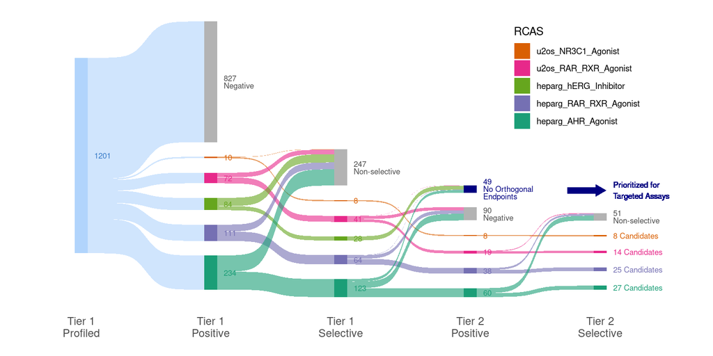

```r
plot_attr <- combined_attr %>%
  make_long(tier1meas, tier1pos, tier1sel, tier2pos, tier2sel) %>%
  mutate(across(
    c(node, next_node), ~ factor(., levels = labels_attr)
  )) %>%
  left_join(., counts_attr, by = c("x", "node")) %>%
  ggplot(aes(
    x = x,
    next_x = next_x,
    node = node,
    next_node = next_node,
    fill = node,
    label = count_label
  )) +
  geom_sankey(na.rm = TRUE, flow.alpha = 0.6, space = 100) +
  geom_sankey_text(
    aes(color = node),
    size = 2.2,
    space = 100,
    hjust = 0,
    position = position_nudge(x = 0.1),
    lineheight = 0.8
  ) +
  geom_segment(
    aes(x = 4.75, y = -239, xend = 5, yend = -239),
    arrow = arrow(length = unit(0.005, "npc"), type = "closed"),
    lineend = "butt",
    linejoin = "mitre",
    color = "navy",
    linewidth = 2.2
  ) +
  geom_text(
    aes(x = 5, y = -239, label = "Prioritized for\nTargeted Assays"),
    color = "navy",
    size = 2.2,
    hjust = 0,
    nudge_x = 0.1,
    fontface = "plain"
  ) +
  scale_fill_manual(
    values = fill_attr, breaks = labels_attr[1:5], na.value = "white"
  ) +
  scale_color_manual(
    values = color_attr, breaks = labels_attr[1:5], na.value = "white"
  ) +
  scale_x_discrete(labels = c(
    "Tier 1\nProfiled",
    "Tier 1\nPositive",
    "Tier 1\nSelective",
    "Tier 2\nPositive",
    "Tier 2\nSelective"
  )) +
  coord_cartesian(clip = "off") +
  labs(x = "", fill = "RCAS") +
  # theme_bw() +
  th_sankey +
  th +
  theme(
    axis.title.y = element_blank(),
    legend.position = c(0.85, 0.75),
    legend.text = element_text(size = 7),
    legend.title = element_text(size = 9),
    legend.key.size = unit(5, "mm"),
    plot.margin = unit(c(0, 1, 0, 0), "cm")
  ) +
  guides(color = "none", fill = guide_legend(reverse = TRUE))

plot_attr
```

## 4.2 Evaluate Tier 1 Performance: Association Tests

As an initial test for how well Tier 1 outcomes are associated with targeted assay results, Fisher’s exact tests are used to determine whether a positive outcome from each RCAS is assocaiated with a positive outcome from at least one orthogonal ToxCast endpoint.

```r
# run exact tests on all rcas
calcFisher <- function(df, col_x, col_y, fisher = TRUE, simulate.p.values = FALSE) {
  contingency <- table(df[[col_x]], df[[col_y]], dnn = c(col_x, col_y))
  if (!any(dim(contingency) == 0)) {
    assoc <- chisq.test(contingency, simulate.p.value = simulate.p.values)
    assoc_export <- broom::tidy(assoc)
    if (fisher) {
      assoc_export$fisher.p.value <- fisher.test(contingency)$p.value
    } else {
      assoc_export$fisher.p.value <- NA
    }
    return(list(test = assoc_export, tbls = broom::augment(assoc)))
  } else {
    return(data.frame())
  }
}
calcOdds <- function(df, col_x, col_y) {
  contingency <- table(df[[col_x]], df[[col_y]], dnn = c(col_x, col_y))
  if (!any(dim(contingency) == 0)) {
    fisher <- fisher.test(contingency)
    fisher_export <- broom::tidy(fisher)
    return(fisher_export)
  } else {
    return(data.frame())
  }
}

# test associations and calculate odds ratios for all rcas but hERG_Inhibitor
  # (no Tier 2 multi-concentration bioactivity estimates available)
assoc_positive <- list(test = data.frame(), tbls = data.frame())
or_positive <- data.frame()
for (sig in unique(combined_sum$source_signature)) {
  assoc <- combined_sum %>%
    filter(source_signature == sig) %>%
    distinct(dtxsid, tier2_positive, .keep_all = TRUE) %>%
    calcFisher(., "tier1_positive", "tier2_positive")
  or <- combined_sum %>%
    filter(source_signature == sig) %>%
    distinct(dtxsid, tier2_positive, .keep_all = TRUE) %>%
    calcOdds(., "tier1_positive", "tier2_positive")
  if (sig != "heparg_hERG_Inhibitor") {
    assoc_positive$test <- rbind(assoc_positive$test, cbind(assoc$test, source_signature = sig))
    assoc_positive$tbls <- rbind(assoc_positive$tbls, cbind(assoc$tbls, source_signature = sig))
    or_positive <- rbind(or_positive, cbind(or, source_signature = sig))
  }
}
```

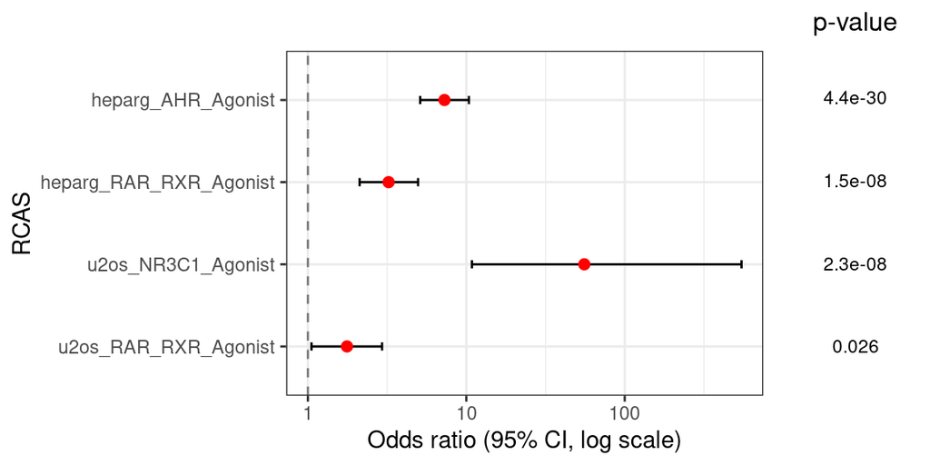

```r
# visualize odds ratios
plot_or <- or_positive %>%
  ggplot() +
  geom_vline(xintercept = 1, linetype = "dashed", color = "grey50") +
  geom_errorbar(
    aes(y = source_signature, xmin = conf.low, xmax = conf.high),
    width = 0.1
  ) +
  geom_point(aes(estimate, source_signature), color = "red", size = 2) +
  scale_x_log10() +
  scale_y_discrete(limits = rev) +
  labs(x = "Odds ratio (95% CI, log scale)", y = "RCAS", title = " ") +
  theme_bw() +
  th

# combine plot with exact test p-values
plot_pval <- or_positive %>%
  mutate(p.value = signif(p.value, digits = 2), siglabel = as.factor(1:4)) %>%
  ggplot(aes(x = as.factor(1), y = siglabel, label = p.value)) +
  geom_text(size = 3) +
  scale_y_discrete(limits = rev) +
  labs(y = NULL, x = " ", title = "p-value") +
  th +
  theme(
    plot.title = element_text(hjust = 0.5, size = 12),
    axis.text.y = element_blank(),
    axis.title.y = element_blank(),
    axis.text.x = element_text(color = "white"),
    axis.line = element_blank(),
    axis.ticks.x = element_blank(),
    axis.ticks.y = element_blank(),
    panel.background = element_blank(),
    panel.border = element_blank(),
    panel.grid.major = element_blank(),
    panel.grid.minor = element_blank(),
    plot.background = element_blank()
    # plot.margin = unit(c(5.5, 0, 5.5, 0), "pt")
  )# +
  # ggtitle("p-value")

plot_or_all <- cowplot::plot_grid(
  plot_or, plot_pval, nrow = 1, rel_widths = c(1, 0.2)
)
plot_or_all
```

```r
# combine panels for Figure 2
fmwk <- png::readPNG(paste0(dir_home, "vignettes/Fig2A.png"))
fmwk_grob <- grid::rasterGrob(fmwk)

plot_fig2 <- cowplot::plot_grid(
  fmwk_grob,
  plot_attr,
  cowplot::plot_grid(
    NULL, plot_or, plot_pval, NULL,
    nrow = 1, rel_widths = c(0.3, 1, 0.2, 0.3)
  ),
  nrow = 3, rel_heights = c(0.6, 1.2, 0.8),
  labels = c("A", "B", "C"), label_fontfamily = "Helvetica"
)
ggsave(
  paste0(dir_home, "output/Fig2.png"), plot_fig2,
  width = 1000, height = 1200, units = "px", scale = 2, bg = "white"
)
```

## 4.3 Evaluate Tier 1 Sensitivity: Mismatching Outcomes

In order to examine the extent to which Tier 1 targeted assessments fail to prioritize targeted perturbagens, Tier 2 potency estimates for chemicals with a negative Tier 1 outcome and a positive or selective Tier 2 outcome are compared to those with a positive or selective Tier 1 outcome via Kruskal-Wallis tests.

```r
# test for effect of tier 1 outcome on tier 2-positive/selective chemicals
mismatch_test <- combined_sum %>%
  filter(tier2_positive & n_toxcast_meas >= 2) %>%
  group_by(source_signature, tier2_selective) %>%
  mutate(n_groups = length(unique(outcome_tier1))) %>%
  filter(n_groups > 1) %>%
  nest() %>%
  mutate(
    kw = purrr::map(data, ~ kruskal.test(.x$modl_acc ~ .x$outcome_tier1)),
    kw_df = purrr::map(kw, broom::tidy)
  ) %>%
  unnest(kw_df) %>%
  ungroup() %>%
  mutate(fdr = p.adjust(p.value, method = "fdr"))

mismatch_test %>%
  select(-c(data, kw)) %>%
  mutate(across(where(is.numeric), ~ signif(.x, 2))) %>%
  rename(rcas = source_signature) %>%
  DT::datatable()
```

|  | tier2_selective | rcas | statistic | p.value | parameter | method | fdr |
| --- | --- | --- | --- | --- | --- | --- | --- |
| 1 | False | heparg_RAR_RXR_Agonist | 12 | 0.0031 | 2 | Kruskal-Wallis rank sum test | 0.0054 |
| 2 | True | heparg_AHR_Agonist | 17 | 0.00022 | 2 | Kruskal-Wallis rank sum test | 0.00077 |
| 3 | False | heparg_AHR_Agonist | 5.8 | 0.055 | 2 | Kruskal-Wallis rank sum test | 0.064 |
| 4 | True | heparg_RAR_RXR_Agonist | 24 | 7.5e-06 | 2 | Kruskal-Wallis rank sum test | 5.3e-05 |
| 5 | False | u2os_RAR_RXR_Agonist | 3.7 | 0.16 | 2 | Kruskal-Wallis rank sum test | 0.16 |
| 6 | True | u2os_RAR_RXR_Agonist | 12 | 0.002 | 2 | Kruskal-Wallis rank sum test | 0.0047 |
| 7 | True | u2os_NR3C1_Agonist | 5 | 0.025 | 1 | Kruskal-Wallis rank sum test | 0.035 |

```r
# test individual contrasts via Wilcoxon rank sum tests
mismatch_contr <- combined_sum %>%
  filter(tier2_positive & n_toxcast_meas >= 2) %>%
  group_by(source_signature, tier2_selective) %>%
  mutate(n_groups = length(unique(outcome_tier1))) %>%
  filter(n_groups > 1) %>%
  nest() %>%
  mutate(
    rs = purrr::map(
      data, ~ pairwise.wilcox.test(
        .x$modl_acc, .x$outcome_tier1,  p.adjust.method = "BH"
      )
    ),
    rs_df = purrr::map(rs, broom::tidy)
  ) %>%
  unnest(rs_df) %>%
  ungroup()

# visualize differences in potency across tier 2-selective only chemicals
contr_pos <- mismatch_contr %>%
  filter(!tier2_selective & group2 == "negative") %>%
  arrange(source_signature, group1) %>%
  mutate(p_label = case_when(
    p.value < 0.001 ~ formatC(p.value, format = "e", digits = 2),
    TRUE ~ as.character(signif(p.value, 2))
  )) %>%
  pull(p_label)

# repeat for tier 2-selective chemicals
contr_sel <- mismatch_contr %>%
  filter(tier2_selective & group2 == "negative") %>%
  arrange(source_signature, group1) %>%
  mutate(p_label = case_when(
    p.value < 0.001 ~ formatC(p.value, format = "e", digits = 2),
    TRUE ~ as.character(signif(p.value, 2))
  )) %>%
  pull(p_label)
```

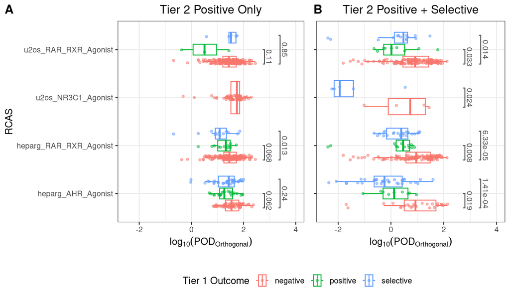

```r
tier2_lim <- c(-2.5, 4)
plot_mismatch_pos <- combined_sum %>%
  filter(
    source_signature != "heparg_hERG_Inhibitor" &
      tier2_positive &
      !tier2_selective
  ) %>%
  ggplot(aes(modl_acc, source_signature, color = outcome_tier1)) +
  geom_boxplot(na.rm = TRUE, outlier.shape = NA) +
  geom_point(
    na.rm = TRUE, size = 1, alpha = 0.5,
    position = position_jitterdodge(jitter.width = 0.1)
  ) +
  geom_signif(
    # y_position = c(3, 3.6, 3, 3.6, 3, 3.6),
    y_position = c(2.8, 3.4, 2.8, 3.4, 2.8, 3.4),
    xmin = c(0.7, 0.7, 1.7, 1.7, 3.7, 3.7),
    xmax = c(1, 1.3, 2, 2.3, 4, 4.3),
    annotation = contr_pos,
    tip_length = 0.01,
    color = "grey30",
    textsize = 3,
    family = "Helvetica"
  ) +
  scale_x_continuous(limits = tier2_lim) +
  labs(
    x = expression(log[10](POD[Orthogonal])), y = "RCAS", color = "Tier 1 Outcome",
    title = "Tier 2 Positive Only"
  ) +
  theme_bw() +
  th +
  theme(legend.position = "bottom", plot.title = element_text(hjust = 0.5))

plot_mismatch_sel <- combined_sum %>%
  filter(
    source_signature != "heparg_hERG_Inhibitor" &
      tier2_positive &
      tier2_selective
  ) %>%
  ggplot(aes(modl_acc, source_signature, color = outcome_tier1)) +
  geom_boxplot(na.rm = TRUE, outlier.shape = NA) +
  geom_point(
    na.rm = TRUE, size = 1, alpha = 0.5,
    position = position_jitterdodge(jitter.width = 0.1)
  ) +
  geom_signif(
    # y_position = c(3, 3.6, 3, 3.6, 3, 3, 3.6),
    y_position = c(2.8, 3.4, 2.8, 3.4, 2.8, 2.8, 3.4),
    xmin = c(0.7, 0.7, 1.7, 1.7, 2.8, 3.7, 3.7),
    xmax = c(1, 1.3, 2, 2.3, 3.2, 4, 4.3),
    annotation = contr_sel,
    tip_length = 0.01,
    color = "grey30",
    textsize = 3,
    family = "Helvetica"
  ) +
  scale_x_continuous(limits = tier2_lim) +
  labs(
    x = expression(log[10](POD[Orthogonal])), y = "RCAS", color = "Tier 1 Outcome",
    title = "Tier 2 Positive + Selective"
  ) +
  theme_bw() +
  th +
  theme(legend.position = "bottom", plot.title = element_text(hjust = 0.5))

plot_mismatch_all <- cowplot::plot_grid(
  cowplot::plot_grid(
    plot_mismatch_pos + theme(legend.position = "none"),
    plot_mismatch_sel + theme(
      axis.text.y = element_blank(),
      axis.title.y = element_blank(),
      legend.position = "none"
    ),
    labels = c("A", "B"),
    label_fontfamily = "Helvetica",
    rel_widths = c(1, 0.65)
  ),
  cowplot::plot_grid(
    NULL, cowplot::get_legend(plot_mismatch_sel), rel_widths = c(0.2, 1)
  ),
  nrow = 2, rel_heights = c(1, 0.2)
)
ggsave(
  paste0(dir_home, "output/Fig3.png"), plot_mismatch_all,
  width = 1200, height = 720, units = "px", scale = 2, bg = "white"
)
plot_mismatch_all
```

## 4.4 Compare Tier 1 POD Sensitivity

In order to examine whether RCAS-derived PODs are health-protective compared to previous PODs derived from transcriptomics and targeted screening data, RCAS- derived BMDs are compared to 5th percentile overall HTTr BMDs (i.e. Biological Phenotype Altering Concentrations, BPACs) ($POD_{BPAC-HTTr}$) and ToxCast orthogonal BMDs ($POD_{Orthogonal}$).

```r
# calculate correlation between RCAS BMDs and HTTr BPACs
calcCor <- function(combined_sum, col_compare, tier2 = FALSE) {
  if (tier2) {
    combined_filt <- combined_sum %>%
      filter(
        n_toxcast_meas >= 2 &
        outcome_tier1 == "selective" &
        outcome_tier2 != "negative"
      ) %>%
      group_by(source_signature, outcome_tier2)
  } else {
    combined_filt <- combined_sum %>%
      filter(outcome_tier1 != "negative") %>%
      group_by(source_signature, outcome_tier1)
  }
  cor_rcas <- combined_filt %>%
    distinct(dtxsid, source_signature, .keep_all = TRUE) %>%
    mutate(bmd_compare = !!as.name(col_compare)) %>%
    select(dtxsid, bmd_log, bmd_compare) %>%
    filter(!is.na(bmd_compare) & is.finite(bmd_compare)) %>%
    nest() %>%
    mutate(n_chems = unlist(purrr::map(data, nrow))) %>%
    filter(n_chems >= 3) %>%
    mutate(
      cor_obj = purrr::map(data, ~ cor.test(.x$bmd_log, .x$bmd_compare)),
      cor_df = purrr::map(cor_obj, broom::tidy)
    ) %>%
    unnest(cor_df) %>%
    mutate(
      cor_label = case_when(
        p.value <= 0.05 ~ paste0("r = ", round(estimate, 2), "*"),
        TRUE ~ paste0("r = ", round(estimate, 2))
      )
    ) %>%
    select(-data, -cor_obj)
  if (tier2) {
    cor_rcas <- mutate(
      cor_rcas,
      outcome_label = case_when(
        outcome_tier2 == "selective" ~ "Positive + Selective",
        TRUE ~ "Positive Only"
      )
    )
  } else {
    cor_rcas <- mutate(
      cor_rcas,
      outcome_label = case_when(
        outcome_tier1 == "selective" ~ "Positive + Selective",
        TRUE ~ "Positive Only"
      )
    )
  }
  return(cor_rcas)
}

cor_bpac <- calcCor(combined_sum, "bmd_log_5")
cor_bpac %>%
  select(-c(n_chems, alternative, cor_label, outcome_label, method)) %>%
  mutate(across(where(is.numeric), ~signif(.x, 2))) %>%
  DT::datatable()
```

|  | source_signature | outcome_tier1 | estimate | statistic | p.value | parameter | conf.low | conf.high |
| --- | --- | --- | --- | --- | --- | --- | --- | --- |
| 1 | heparg_AHR_Agonist | selective | 0.86 | 18 | 8.8e-37 | 120 | 0.8 | 0.9 |
| 2 | heparg_AHR_Agonist | positive | 0.9 | 22 | 1.9e-41 | 110 | 0.86 | 0.93 |
| 3 | heparg_RAR_RXR_Agonist | selective | 0.67 | 7 | 1.9e-09 | 62 | 0.5 | 0.78 |
| 4 | heparg_RAR_RXR_Agonist | positive | 0.96 | 22 | 2.1e-25 | 45 | 0.92 | 0.97 |
| 5 | heparg_hERG_Inhibitor | positive | 0.8 | 9.9 | 1.1e-13 | 54 | 0.68 | 0.88 |
| 6 | heparg_hERG_Inhibitor | selective | 0.97 | 22 | 3.6e-18 | 26 | 0.94 | 0.99 |
| 7 | u2os_RAR_RXR_Agonist | positive | 0.91 | 12 | 1.5e-12 | 29 | 0.82 | 0.96 |
| 8 | u2os_RAR_RXR_Agonist | selective | 0.92 | 15 | 1.4e-17 | 39 | 0.86 | 0.96 |
| 9 | u2os_NR3C1_Agonist | selective | 0.66 | 2.1 | 0.077 | 6 | -0.089 | 0.93 |

```r
cor_tier2 <- calcCor(combined_sum, "modl_acc", tier2 = TRUE)
cor_tier2 %>%
  select(-c(n_chems, alternative, cor_label, outcome_label, method)) %>%
  mutate(across(where(is.numeric), ~signif(.x, 2))) %>%
  DT::datatable()
```

|  | source_signature | outcome_tier2 | estimate | statistic | p.value | parameter | conf.low | conf.high |
| --- | --- | --- | --- | --- | --- | --- | --- | --- |
| 1 | heparg_AHR_Agonist | selective | 0.48 | 2.8 | 0.011 | 25 | 0.13 | 0.73 |
| 2 | heparg_RAR_RXR_Agonist | positive | 0.71 | 3.4 | 0.0062 | 11 | 0.27 | 0.91 |
| 3 | heparg_AHR_Agonist | positive | 0.19 | 1.1 | 0.3 | 31 | -0.17 | 0.5 |
| 4 | heparg_RAR_RXR_Agonist | selective | 0.6 | 3.6 | 0.0014 | 23 | 0.27 | 0.81 |
| 5 | u2os_NR3C1_Agonist | selective | 0.96 | 8.9 | 0.00011 | 6 | 0.81 | 0.99 |
| 6 | u2os_RAR_RXR_Agonist | selective | 0.92 | 8.2 | 3.1e-06 | 12 | 0.76 | 0.97 |
| 7 | u2os_RAR_RXR_Agonist | positive | 0.34 | 0.62 | 0.58 | 3 | -0.78 | 0.94 |

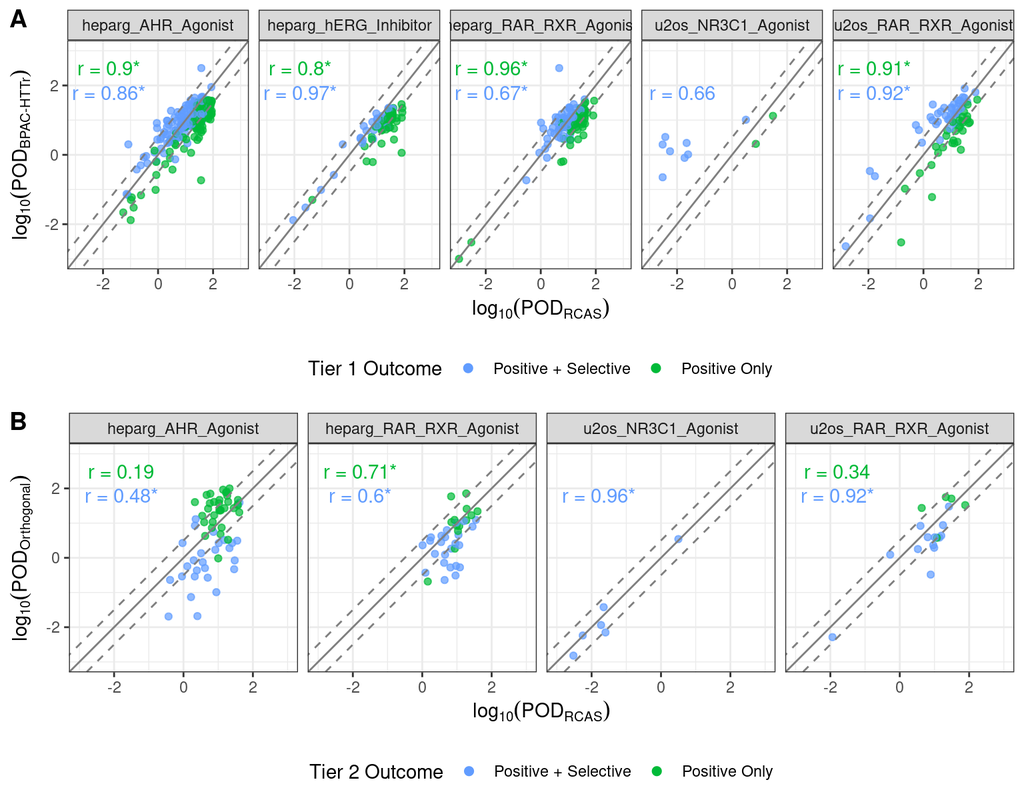

```r
# plot RCAS BMDs against HTTr BPACs/Tier 2 PODs
plotPods <- function(combined_sum, cor_rcas, col_compare, label_compare, tier2 = FALSE) {
  if (tier2) {
    combined_filt <- filter(
      combined_sum,
      n_toxcast_meas >= 2 &
      outcome_tier1 == "selective" &
      outcome_tier2 != "negative"
    ) %>%
      mutate(
        outcome_label = case_when(
          outcome_tier2 == "selective" ~ "Positive + Selective",
          TRUE ~ "Positive Only"
        )
      )
  } else {
    combined_filt <- filter(combined_sum, outcome_tier1 != "negative") %>%
      mutate(
        outcome_label = case_when(
          outcome_tier1 == "selective" ~ "Positive + Selective",
          TRUE ~ "Positive Only"
        )
      )
  }
  plot_pod <- combined_filt %>%
    distinct(dtxsid, source_signature, .keep_all = TRUE) %>%
    ggplot(aes(bmd_log, !!as.name(col_compare), color = outcome_label)) +
    geom_point(na.rm = TRUE, alpha = 0.7) +
    geom_abline(
      slope = 1, intercept = c(-0.5, 0.5),
      linetype = "dashed", color = "grey50"
    ) +
    geom_abline(slope = 1, intercept = 0, color = "grey50") +
    geom_text(
      data = filter(cor_rcas, outcome_label == "Positive Only"),
      aes(label = cor_label),
      x = -1.8, y = 2.5, show.legend = FALSE
    ) +
    geom_text(
      data = filter(cor_rcas, outcome_label == "Positive + Selective"),
      aes(label = cor_label),
      x = -1.8, y = 1.8, show.legend = FALSE
    ) +
    facet_wrap(~source_signature, nrow = 1) +
    labs(
      x = bquote(log[10](POD[RCAS])),
      y = bquote(log[10](POD[.(label_compare)]))
    ) +
    scale_color_manual(values = scales::hue_pal()(3)[c(3, 2)]) +
    scale_x_continuous(limits = c(-3, 3)) +
    scale_y_continuous(limits = c(-3, 3)) +
    theme_bw() +
    th +
    theme(legend.position = "bottom") +
    guides(label = "none")

  if (tier2) {
    plot_pod <- plot_pod + labs(color = "Tier 2 Outcome")
  } else {
    plot_pod <- plot_pod + labs(color = "Tier 1 Outcome")
  }
  return(plot_pod)
}

plot_bpac <- plotPods(combined_sum, cor_bpac, "bmd_log_5", "BPAC-HTTr")
plot_tier2 <- plotPods(combined_sum, cor_tier2, "modl_acc", "Orthogonal", tier2 = TRUE)

# combine plots
guide_or <- guides(color = guide_legend(override.aes = list(alpha = 1, size = 2)))
plot_pod_all <- cowplot::plot_grid(
  plot_bpac + guide_or,
  plot_tier2 + guide_or,
  nrow = 2, labels = c("A", "B"), label_fontfamily = "Helvetica"
)
ggsave(
  paste0(dir_home, "output/Fig4.png"), plot_pod_all,
  width = 1400, height = 1100, units = "px", bg = "white", scale = 2
)

plot_pod_all
```

## 4.5 Inspect Candidate Perturbagens

Tier 1/2 data are compiled for chemicals that met tier1- and tier2-selective criteria for comparison of potency estimates across targeted assays. PODs include $POD_{RCAS}$, $POD_{Orthogonal}$, and non-selective ToxCast-derived PODs ($POD_{NS-ToxCast}$)

Chemical structure images used in Fig. 5 were downloaded from the [EPA CompTox Chemicals Dashboard](https://comptox.epa.gov/dashboard/), and were stored in the `data/ccd_structures` directory using a `structure_<chem_name>.png` naming convention (not included in repo due to size constraints).

```r
# filter data per target + process for plotting
compileTargetData <- function(combined_full, rcas, struct) {
  combined_full <- arrange(combined_full, signature_label, source)
  combined_filt <- combined_full %>%
    filter(
      source_signature == rcas &
        tier1_selective &
        tier2_selective &
        n_toxcast_meas >= 2
    )
  combined_proc <- combined_filt %>%
    group_by(dtxsid) %>%
    mutate(
      n_specific = n(),
      aenm_annot = tier2_annot[["Ref."]][
        match(aenm, tier2_annot[["Assay.Endpoint"]])
      ],
      aenms_specific = list(aenm_annot),
      chem_category = case_when(
        !is.na(ref_class) & ref_class == signature_label ~ "in-class reference",
        !is.na(ref_class) & ref_class != signature_label ~ "out-of-class reference",
        is.na(ref_class) ~ "test chemical"
      ),
      signature_f = case_when(
        chem_category == "in-class reference" ~ "Reference Chemical",
        TRUE ~ paste0("Tier 1/2 Candidate: ", source_signature)
      ),
      signature_f = factor(
        signature_f,
        levels = c(
          "Reference Chemical", paste0(
            "Tier 1/2 Candidate: ", unique(
              filter(
                combined_full,
                tier1_selective & tier2_selective & n_toxcast_meas >= 2
              )$source_signature
            )
          )
        )
      ),
      signature_s = as.character(signature_f),
      name_label = case_when(
        tolower(name) %in% names(struct) |
          chem_category == "in-class reference" ~ name,
        TRUE ~ ""
      )
    ) %>%
    slice_min(modl_acc, n = 1) %>%
    ungroup() %>%
    mutate(acc_rank = row_number(modl_acc)) %>%
    group_by(dtxsid) %>%
    pivot_longer(
      cols = c(modl_acc, modl_acc_mode, bmd_log),
      names_to = "metric",
      values_to = "value"
    )
  return(combined_proc)
}
```

```r
plotCandidates <- function(combined_proc) {
  plot_set <- sort(unique(unlist(pull(combined_proc, aenms_specific))))
  plot_candidates <- ggplot() +
    geom_line(
      data = filter(combined_proc, metric != "bmd_log"),
      aes(x = aenms_specific, y = value, color = signature_f, group = acc_rank),
      alpha = 0.8, position = position_dodge(width = .7)
    ) +
    geom_point(
      data = combined_proc,
      aes(
        x = aenms_specific, y = value,
        color = signature_f, group = acc_rank, shape = metric
      ),
      size = 2, alpha = 0.8, fill = "white",
      position = position_dodge(width = .7)
    ) +
    scale_x_upset(order_by = "degree", sets = plot_set) +
    geom_text_repel(
      data = filter(combined_proc, metric == "modl_acc"),
      aes(
        x = aenms_specific, y = value,
        color = signature_f, group = acc_rank, label = name_label
      ),
      position = position_dodge(width = 0.7),
      max.overlaps = 50,
      size = 3,
      min.segment.length = 0,
      box.padding = 0.7,
      segment.curvature = 0.2,
      segment.ncp = 3,
      segment.angle = 20,
      segment.linetype = 3
    ) +
    scale_color_manual(
      values = c(
        "grey20",
        brewer.pal(length(levels(combined_proc$signature_f)) - 1, "Dark2")
      ), drop = FALSE
    ) +
    scale_shape_manual(
      values = c(4, 16, 21),
      labels = expression(POD[RCAS], POD[Orthogonal], POD[`NS-ToxCast`])
    ) +
    # facet_wrap(~source_signature, nrow = 1) +
    labs(
      x = "", y = "log10(POD)",
      shape = "Metric", color = "Chemical Type"
    ) +
    theme_bw() +
    th +
    guides(
      shape = guide_legend(nrow = 1, label.hjust = 0),
      color = guide_legend(ncol = 1)
    )
  return(plot_candidates)
}
```

```r
# import pngs for chemical structures
dir_structs <- paste0(dir_home, "data/ccd_structures/")
structs <- list()
for (filename_struct in list.files(dir_structs)) {
  chemname <- gsub(".png", "", gsub("structure_", "", filename_struct))
  struct_png <- png::readPNG(paste0(dir_structs, filename_struct))
  # struct_dim <- dim(struct_png)[2:1]
  struct_grob <- grid::rasterGrob(struct_png)
  structs[[chemname]] <- struct_grob
}
struct_plot <- list()
struct_plot[["AHR"]] <- cowplot::plot_grid(
  structs[["1-4-diaminoanthraquinone"]], structs[["3-hydroxyfluorene"]],
  structs[["2-aminoanthraquinone"]],
  labels = c("1,4-Diaminoanthraquinone", "3-Hydroxyfluorene", "2-Aminoanthraquinone"),
  label_fontface = "plain", label_size = 10, label_fontfamily = "Helvetica",
  label_x = 0.5, label_y = 1, hjust = 0.5
)
struct_plot[["GR"]] <- cowplot::plot_grid(
  structs[["fluorometholone"]], structs[["budesonide"]],
  structs[["medroxyprogesterone-acetate"]],
  labels = c("Fluorometholone", "Budesonide", "Medroxyprogesterone acetate"),
  label_fontface = "plain", label_size = 10, label_fontfamily = "Helvetica",
  label_x = 0.5, label_y = 1, hjust = 0.5
)
struct_plot[["RAR"]] <- cowplot::plot_grid(
  structs[["etoxazole"]], structs[["imazalil"]],
  structs[["dieldrin"]], structs[["aldrin"]],
  labels = c("Imazalil", "Prochloraz", "Aldrin", "Dieldrin"),
  label_fontface = "plain", label_size = 10, label_fontfamily = "Helvetica",
  label_x = 0.5, label_y = 1, hjust = 0.5
)
```

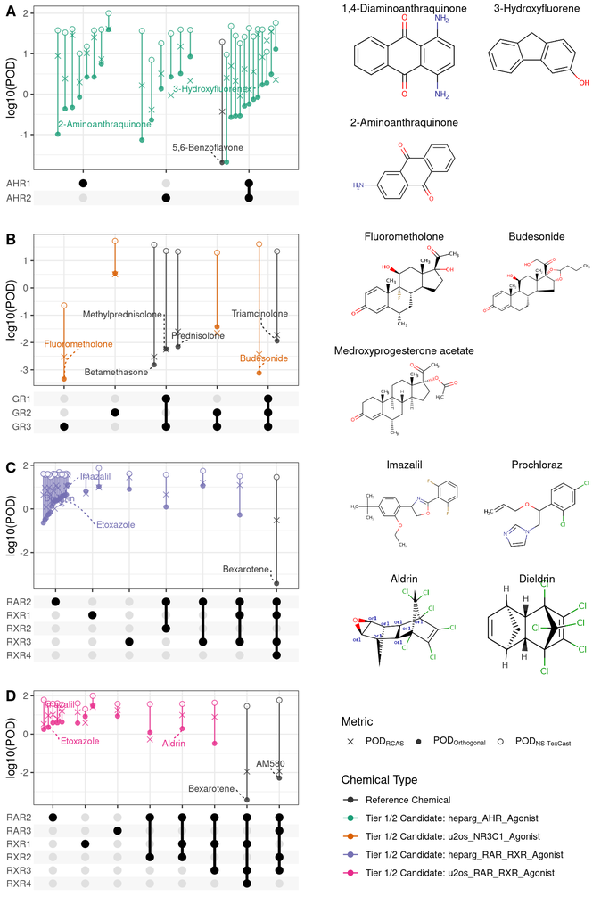

```r
plots_candidate <- list()
for (target in unique(combined_full$source_signature)) {
  if (target != "heparg_hERG_Inhibitor") {
    combined_target <- compileTargetData(combined_full, target, structs)
    plots_candidate[[target]] <- plotCandidates(combined_target)
  }
}

# pull legend for separate panel
lgd <- cowplot::get_legend(
  plots_candidate[["heparg_AHR_Agonist"]] +
    theme(legend.position = "right") +
    guides(
      shape = guide_legend(nrow = 1, title = "Metric", label.hjust = 0),
      color = guide_legend(
        title = "Chemical Type", override.aes = list(label = "", alpha = 1)
      ),
    )
)
# combine figure panels (Fig. 5)
plots_candidate_struct <- cowplot::plot_grid(
  plots_candidate[["heparg_AHR_Agonist"]] + theme(legend.position = "none"),
  struct_plot[["AHR"]],
  plots_candidate[["u2os_NR3C1_Agonist"]] + theme(legend.position = "none"),
  struct_plot[["GR"]],
  plots_candidate[["heparg_RAR_RXR_Agonist"]] + theme(legend.position = "none"),
  struct_plot[["RAR"]],
  plots_candidate[["u2os_RAR_RXR_Agonist"]] + theme(legend.position = "none"),
  lgd,
  labels = c("A", "", "B", "", "C", "", "D", ""),
  label_fontfamily = "Helvetica",
  axis = "btlr",
  align = "v",
  ncol = 2
)
ggsave(
  paste0(dir_home, "output/Fig5.png"), plots_candidate_struct,
  width = 1600, height = 2400, units = "px", scale = 1.6, bg = "white"
)
plots_candidate_struct
```